# Lab 11 - Data, Aesthetics, & Geometries

Yana Chakalo

November 14, 2017

## Installing packages that i might need to use.

```r
options(repos = c(CRAN = "http://cran.rstudio.com"))
install.packages("dplyr")
install.packages("packrat")
install.packages("readr")
install.packages("foreign")
install.packages("haven")
install.packages("knitr")
install.packages("tidyverse")
library("tidyverse")
library("dplyr")
library("packrat")
library("readr")
library("foreign")
library("haven")
library("knitr")
```

```r
setwd("/Users/soniachakalo/Downloads/Final.Porject.Labs")

opts_knit$set(root.dir = "/Users/soniachakalo/Downloads/Final.Porject.Labs")

getwd()
```

```
## [1] "/Users/soniachakalo/Downloads/Final.Porject.Labs"
```

## Downloading my data set and which variables i want to this lab and to Rstudio.

# Read in your data with the appropriate function

# replace with variable’s you wish to add

# 2002

```r
data2 <- read_tsv("/Users/soniachakalo/Downloads/Final.Porject.Labs/23625_0002_Data.tsv")
data_subset2 <- data2 %>%
  select(CITY, STATECOD, POP1, TNUMVTMS, TNUMOFF, GOFFRAC, BIASMO1, VTYP_I1, LOCCOD1, VTYP_I1, LOCCOD1)
```

# 2013

```r
# Read in your data with the appropriate function
data13 <- read_tsv("/Users/soniachakalo/Downloads/Final.Porject.Labs/36118-0002-Data.tsv")
data_subset13 <- data13 %>%
  select(CITY, STATECOD, POP1, TNUMVTMS, TNUMOFF, GOFFRAC, BIASMO1, VTYP_I1, LOCCOD1, VTYP_I1, LOCCOD1)
# replace with variable's you wish to add
```

Complete the following exercises below. Knit together the PDF document and commit both the Lab 11 RMD file and the PDF document to Git. Push the changes to GitHub so both documents are visible in your public GitHub repository.

1. Which variables in your dataset are you interested in visualizing? Describe the level of measurement of these variables and what type of geography you think is appropriate to represent these variables. Give your reasoning for choosing the `geom_()` you selected.

2. Is your data in the proper format to visualize the data in the way you want? Why or why not? *If you need/want to change the structure of your data, do it below.*

My data is in the format that i want to visualize all the variables I want because they are all categorical so I am able to look at the counts of each variable in each table thus giving me the frequency of the objects i want to see.

3. Create at least two different exploratory plots of the variables you chose using the skills we covered in class today. What types of mapping aesthetics did you choose and why? What do these plots tell you about your data?

# 2002 data set

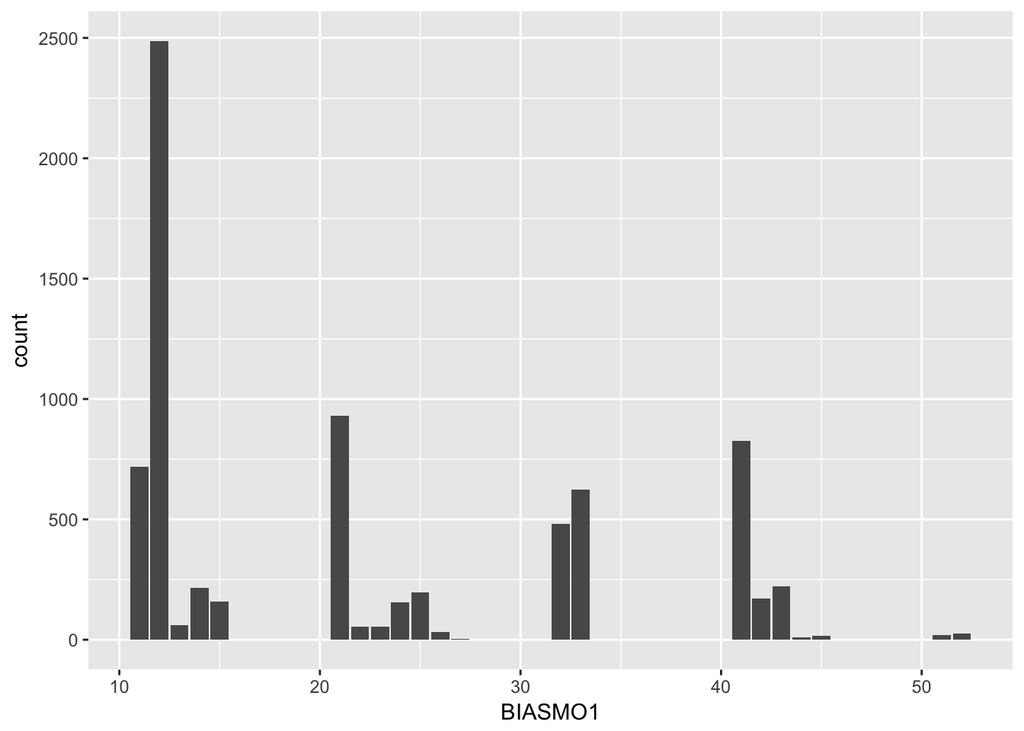

```r
ggplot(data = data_subset2,
    mapping = aes(x = BIASMO1)) +
  geom_bar()
```

# 2013 data set

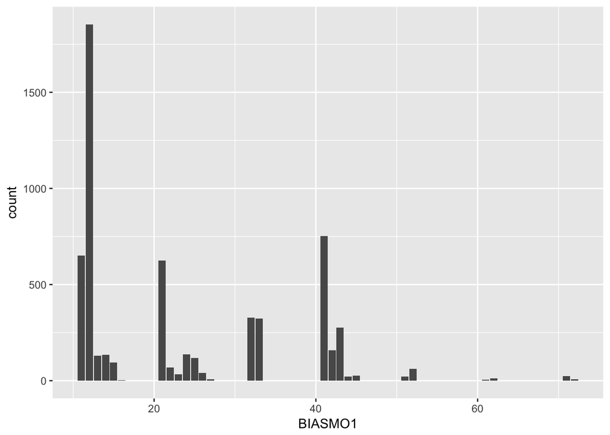

```r
ggplot(data = data_subset13,
    mapping = aes(x = BIASMO1)) +
  geom_bar()
```

4. Create at least three variations of the plots you’ve already made by modifying some of the arguments we covered in class (i.e. `position`, `scale`, `size`, `linetype` etc.). Do any of these modifications help you understand your data better? Why or why not? Do any of them create a misleading interpretation of the relationships between your variables? If yes, how so?

I tried doing modifications to my bar plots but they did not help create a more comprehensive plot. I think the scale is off and there is no definite seperation from different types of bias motives.

# 2002

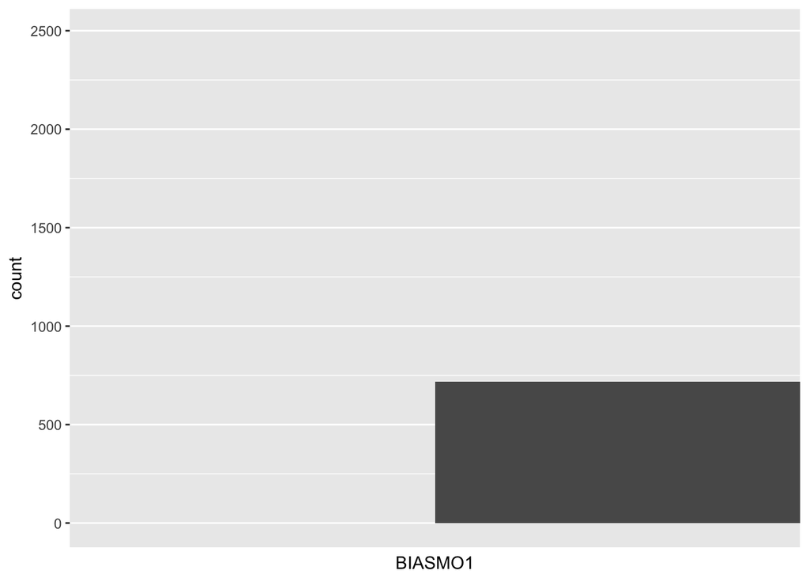

```r
ggplot(data = data_subset2,
       mapping = aes(x = BIASMO1)) +
  scale_x_continuous(
    name = "BIASMO1",
    limits = c(NA),
    breaks = seq(0, 5, 10)) +
  geom_bar()
```

# 2013

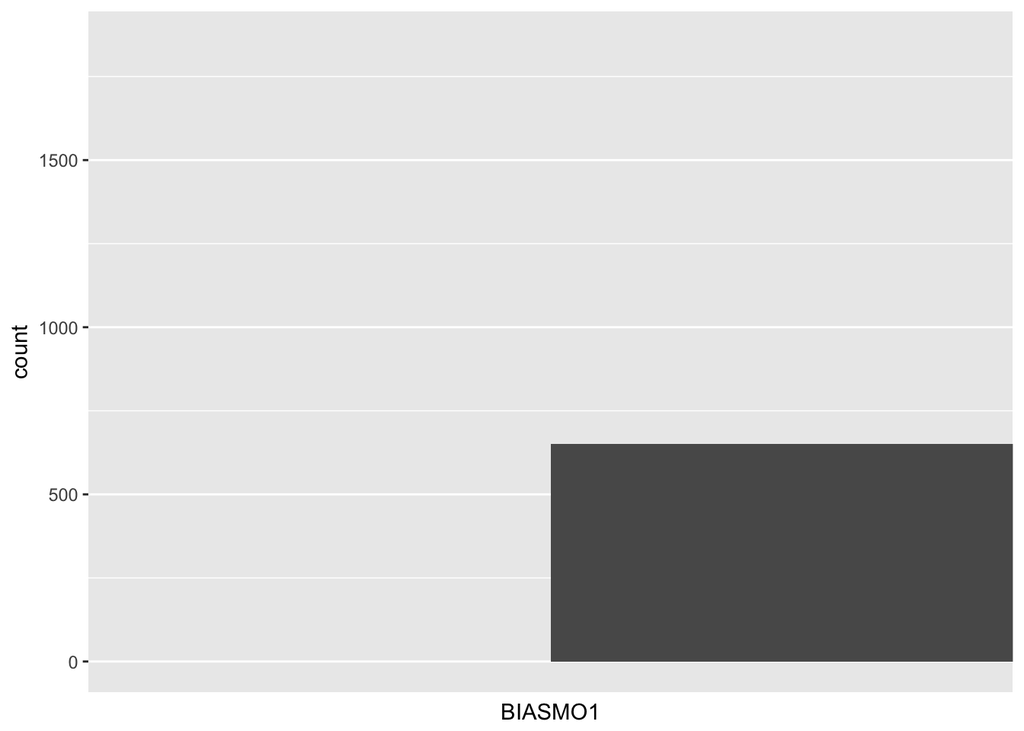

```r
ggplot(data = data_subset13,
       mapping = aes(x = BIASMO1)) +
  scale_x_continuous(
    name = "BIASMO1",
    limits = c(NA),
    breaks = seq(0, 5, 10)) +
  geom_bar()
```

5. From the plots you’ve created thus far, do any of them seem appropriate for a general audience? Why or why not? If so, what do you think you’d still need to do to make them more suitable as explanatory visualizations?

The only plots that i have made so far that might be appropriate for an audience are the first plots from question 3. They actually show a differentiation between bars and frequency’s where you can see pattersn and distinctions. I do however have to find a way to plot every type of bias motive to show individual frequencies which i can then compare to each other and to the other data set.

[figure not shown]

```r
ggplot(data = data_subset13,
       mapping = aes(x = BIASMO1, y = frequency(0, 1000))) +
  scale_x_continuous(
    name = "BIASMO1",
    limits = c(NA),
    breaks = seq(0, 5, 10)) +
  geom_line()
```